# Programação Paralela em Julia: uma História com Suricates - 6 Detecção de Bordas

O objetivo de Daisy é aprimorar seus mapas detectando bordas, e seu algoritmo é muito simples, ela busca por mudanças abruptas na intensidade. Ela fez o desenho abaixo para ilustrar sua ideia, primeiro, ela converte a imagem do mapa em escala de cinza, compara pixels adjacentes, e diz que qualquer pixel acima de um *valor limite* (*threshold*) será considerado uma borda.

[figure not shown]

Depois de detectar as bordas, Daisy pinta a imagem original com pontos `vermelho` para destacá-los. Dessa vez Daisy precisou instalar pacotes em Julia, ela precisou usar o `Images.jl` para carregar uma image de alta resolução do planeta todo.

**Instalar Pacotes**

A primeira maneira de instalar pacotes é com o pacote `Pkg`

```julia
import Pkg
Pkg.add("Images")
```

O segundo método é pelo terminal (também chamado `REPL` de Julia). Você deve apertar o `]` no teclado. Isso vai alterar a palavra chave `julia>` para algo do tipo `(@v1.9) pkg>`. Em seguida, você pode dizer o comando de instalação.

```julia
(@v1.9) pkg> add Images
```

**Será esperado que você instale todos os pacotes futuramente apresentados.**

**Sintaxe: Canais de Cores**

Por padrão, o pacote `Images.jl` vai carregar imagens representadas em `RGB`(red, green, blue).

Existem funções (felizmente) com os mesmos nomes que permitem encontrar os respectivos valores para *cada pixel*.

```julia
sua_imagem = load(".....")
um_pixel = sua_imagem[3,5]
r,g,b = red(um_pixel), green(um_pixel), blue(um_pixel)
```

Mas por exemplo, para encontrar todos os vermelhos de uma imagem, você deve usar o operador broadcast `.`

```julia
sua_imagem = load(".....")
canal_vermelho = red.(sua_imagem)
```

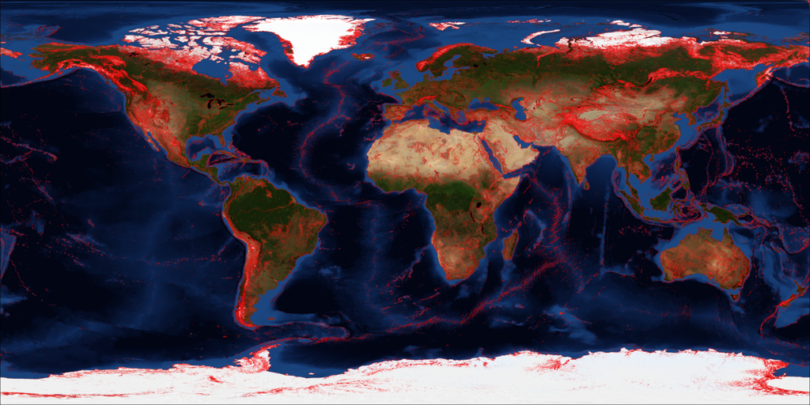

```julia
using Images
vermelho = RGBA(1.0,0,0.,1)
threshold = 0.02

function detectar_bordas(imagem, threshold)
    T = eltype(imagem) # tipo da matriz
    altura, comprimento = size(imagem)
    imagem_nova = zeros(T, altura, comprimento)

    for y = 2:comprimento
        for x = 2:altura
            atual = imagem[x,y]
            acima    = imagem[x-1,y]
            esquerda  = imagem[x,y-1]

            if abs(atual-esquerda) ≥ threshold &&
               abs(atual-acima) ≥ threshold
                # se é uma borda, anota com '1'
                imagem_nova[x,y] = one(T)
            end
        end
    end
    return imagem_nova
end
function pintar_bordas(imagem, mapa_de_bordas, vermelho)
    imagem_com_bordas = deepcopy(imagem)

    um = one(eltype(mapa_de_bordas))
    onde_pintar = findall(mapa_de_bordas .== um)
    imagem_com_bordas[onde_pintar] .= vermelho

    return imagem_com_bordas
end
_original = Images.load(pwd()*"/world.png");
imagem = (red.(_original) +
                green.(_original) +
                blue.(_original))/3

bordas = detectar_bordas(imagem, threshold)
imagem_com_bordas = pintar_bordas(_original, bordas, vermelho)

imagem_com_bordas
```

Esse código foi escrito com loops sem explorar nenhum paralelismo, por isso iremos chamar esse código de versão `sequencial` nas próximas seções.